# Assignment 2

Mouaid Alim

# Background

### Data and Study Objective

In the first assignment, the focus was on analyzing a dataset from the Gene Expression Omnibus (GEO) with the accession number GSE208637, originally generated by a study investigating the role of CD161-expressing CD8+ T cells in chronic Hepatitis B (HBV) infection. The study aimed to understand the profiles and changes of these cells during the infection. Utilizing blood and liver tissue samples from chronic HBV patients, the dataset distinguished between two groups based on the severity of liver injury indicated by Aspartate Aminotransferase (AST) levels—AST>40 representing more severe liver injury and AST<40 representing less severe injury. Figure 1 shows the difference in tissue appearance between the 2 conditions and it is derived from the dataset’s orginial paper Liu et al. (2023). All figures in the Background section are created using the knitr package (Xie (2023)).

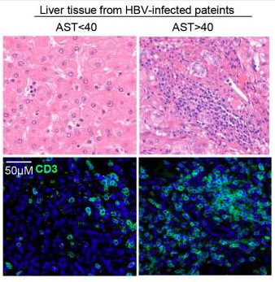

Figure 1: Comparison of Liver tissue from HBV infected patients without liver injury (AST<40) and with Liver injury (AST>40)

This differentiation allowed for an analysis of the impact of liver injury severity on CD161+CD8+ T cells. The dataset, which includes liver tissues from HBV-infected patients, leverages next-generation sequencing on the Illumina platform, offering comprehensive gene coverage. With 10 samples, including biological replicates for both conditions, the dataset provided a robust basis for analysis. Below we can see a table showcasing the samples in the dataset and the names used for them.

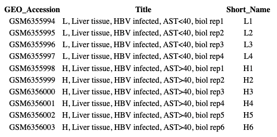

Table 1: Summary of the Dataset Samples, their source and status and the short_name used to represent them

### Filtering & HGNC Mapping

The bioinformatics analysis began by filtering the RNAseq dataset to enhance the quality of the data for differential expression analysis. This was achieved by applying an edgeR-based filtering protocol, where genes with less than 1 read per million in fewer than 4 samples (the smallest number of replicates in a condition) were filtered out. This step ensured the removal of low-abundance genes, which can introduce noise and affect statistical power. This step reduced the number of genes from 56275 to 16697.

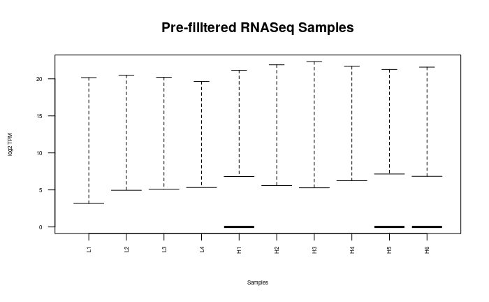

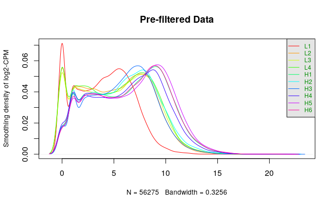

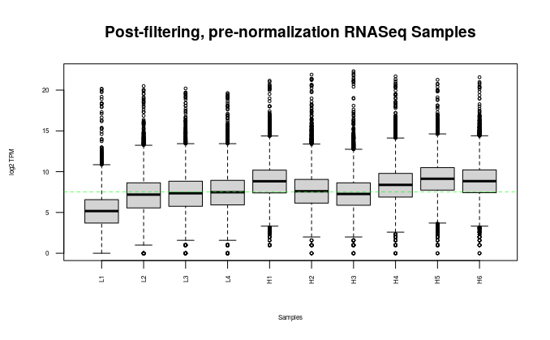

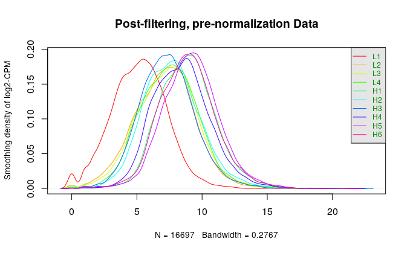

Figure 2: Visualization of data pre and post filtering. Top Left = Pre-filtering Boxplot, Top right = Pre-filtering Density Plot, Bottom Left = Post-filtering boxplot, Bottom Right = Post-filtering Density Plot

After filtering, gene names were mapped to their respective HGNC symbols, ensuring that gene identifiers conformed to standard nomenclature. Out of the original set, 475 non-approved gene symbols were replaced with HGNC-approved symbols, while 2030 remained unmapped.

## Normalization

Next we Normalized the gene counts using Trimmed Mean of M-values normalization method. The boxplot and density plot below showcase the effective standardization of the data due to normalization. An MDS plot also showed noticeable difference between samples of different conditions based on their expression profile.

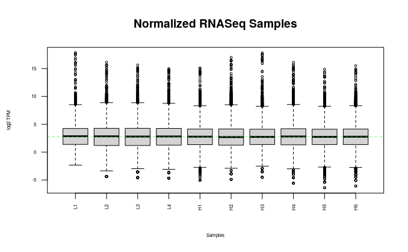

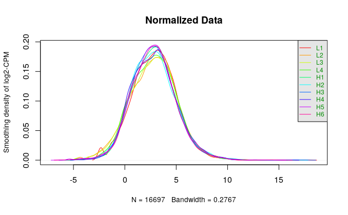

[figure not shown]

# Differential Gene Expression

The first thing to get started with the Differential gene expression analysis is to solidify the model we are working with. This will require us to inspect the MDS plot to see what factors are important to incorporate into the model. Estimating dispersion and carrying our the differential gene expression was done using the edgeR pacakge protocol (Chen et al. (2023))

## Model Design

Based on the MDS plot conducted in the previous section we can conclude that the condition or presence of Liver injury (H/AST>40 or L/AST<40) in the patient is the main factor to consider for the model design. This is what I will be doing.

The first step will be to rerun the code from the previous assignment to have the matrix of normalized data.

## Estimating Dispersion

Before carrying out the differential expression we create a DGEList object to carry out and estimate the dispersion of the counts. This is done to as estimating dispersion is a crucial step in RNA-Seq data analysis for modeling the inherent variability in the data accurately. This step ensures that the statistical tests used to identify deferentially expressed genes are based on realistic assumptions about the data’s behavior, leading to more reliable and interpretable results. It is also required before carrying out differential expression using the negative binomial model used by edgeR.

Moreover, we are setting the levels to be low_AST first meaning, we are setting AST<40 or No Liver injury to tbe the base to which we will compare the expression in the high AST>40 samples to.

```r
# Create DGEList object for dispersion
dispersion_edge_list <- edgeR::DGEList(counts = counts)

# Create groupings from samples
groups <- factor(c('low_AST', 'low_AST', 'low_AST', 'low_AST', 'high_AST', 'high_AST', 'high_AST', 'high_AST', 'high_AST', 'high_AST'), levels = c("low_AST", "high_AST"))
design <- model.matrix(~groups)


# Update the DGEList object with the design matrix
dispersion_edge_list$design <- design

# use the edgeR package to estimate dispersion
dispersion_edge_list <- edgeR::estimateDisp(dispersion_edge_list, design)
```

## Multiple Hypothesis Testing

For Multiple Hypothesis testing or correction we used the Benjamni - Hochberg FDR method. This is the default and built-in method used for the edgeR protocol and is quite a reliable which is why it was chosen.

## Carrying Out Differential Expression

To carry out differential expression we use the Quasi Likelihood fit model as it is the best for Bulk RNAseq data. First we fit the data into the QLfit model and then we run the gene expression analysis on it. We set the coef as groupshigh_AST. This ensures that we are comparing the control or AST<40/No liver injury group which is taken as the default to the AST>40/Liver injury group. We then use topTags to extract the results of the differential expression analysis. Kable was used to plot produce the table of results (Zhu (2021)), edgeR was used for coming up with the topTags (Chen et al. (2023)).

```r
# Fit data into Quasi Liklihood fit model
fit <- edgeR::glmQLFit(dispersion_edge_list, design)

# Run Differentil Gene Expression analyis on the
qlf.low_vs_high <- edgeR::glmQLFTest(fit, coef='groupshigh_AST')

# Extract differential expression analysis results
qlf_output_hits <- edgeR::topTags(qlf.low_vs_high, sort.by = "PValue", n = nrow(counts))

# Plot some of results
kableExtra::kable(edgeR::topTags(qlf.low_vs_high), type="html",row.names =TRUE, align="c")
```

|  | logFC | logCPM | F | PValue | FDR |
| --- | --- | --- | --- | --- | --- |
| AC079922.2 | -10.308860 | 0.862891 | 105.94621 | 0 | 0 |
| CYP7A1 | -6.593369 | 3.729189 | 103.81241 | 0 | 0 |
| LCN2 | 8.577835 | 6.837700 | 92.24921 | 0 | 0 |
| SULT1E1 | -6.018268 | 4.121900 | 91.12740 | 0 | 0 |
| AC004231.2 | 7.511120 | 4.846966 | 82.61385 | 0 | 0 |
| COL4A2-AS1 | 7.691559 | 3.981910 | 80.27909 | 0 | 0 |
| USH2A | -6.158151 | 2.054848 | 79.30567 | 0 | 0 |
| MT1H | -5.687982 | 2.820991 | 78.22792 | 0 | 0 |
| RP11-545J16.1 | -5.694660 | 6.076400 | 77.86219 | 0 | 0 |
| RP11-363E6.3 | 6.899576 | 4.627856 | 74.97956 | 0 | 0 |

|  | x |
| --- | --- |
| 1 | BH |

|  | x |
| --- | --- |
| 1 | groupshigh_AST |

|  | x |
| --- | --- |
| 1 | glm |

**Table 2:** Above we see what the result from the differential expression analysis looks like. logFC represents the log fold change so the relative expression of the gene, logCPM is the relative counts per million of the gene, PValue is the significance of the expression of this gene, and FDR is the significance of expression of the genes after correction. BH indicates that the Benjamni - Hochberg was the used method for multiple hypothesis testing.

## Threshold Selection

When selecting a threshold we want to set one that filters out enough of the genes so that we are only left with the top hits and most relevant and deferentially expressed genes. We will start with the high recommended P-value of 0.05 and adjust accordingly. Below we see the number Significantly deferentially expressed genes passed the initially set P-value Threshold

```r
# Genes that pass the threshold p-value
sprintf("There are %d genes that pass the threshold p-value of 0.05", length(which(qlf_output_hits$table$PValue < 0.05)))
```

```
## [1] "There are 7565 genes that pass the threshold p-value of 0.05"
```

```r
# Genes that pass correction with a threshold of 0.05
sprintf("There are %d genes that pass correction with a threshold of 0.05", length(which(qlf_output_hits$table$FDR < 0.05)))
```

```
## [1] "There are 6077 genes that pass correction with a threshold of 0.05"
```

Due to the large number of genes that pass the threshold, I set the threshold to be a stringent 0.000001 to ensure only a couple hundred genes pass the threshold and so that we only get the top and most important hits. Below we see the number of significanlty deferentially expressed genes that passed both the threshold p-value before and after correction.

```r
# Genes that pass the threshold p-value
sprintf("There are %d Genes that passed the more stringent threshold p-value of 0.000001 ", length(which(qlf_output_hits$table$PValue < 0.000001)))
```

```
## [1] "There are 918 Genes that passed the more stringent threshold p-value of 0.000001 "
```

```r
# Genes that pass correction with a more stringent threshold of 0.000001
sprintf("There are %d Genes that passed correction with the more stringent threshold p-value of 0.000001",
length(which(qlf_output_hits$table$FDR < 0.000001)))
```

```
## [1] "There are 534 Genes that passed correction with the more stringent threshold p-value of 0.000001"
```

This is a good enough value for the number of genes passing correction, as discussed with the prof so we are going with this threshold value.

## MA plot

To visualize the differential gene expression between the the Low AST<40 and the high AST>40 group we us an MD plot as seen below. This plot plots the Average Log of the counts per million (CPM) on the x-axis and the Log Fold Cchange (LogFC) on the y-axis. LogCPM shows us the the average expression level of genes across the two conditions and LogCF shows us how much more or less a gene is expressed in the high AST>40 condition compared to the Low AST<40 condition. By setting the threshold value to be our previously chosen 0.000001 we can highlight the genes that were up regulated and downregulated. Genes that were upregulated are those that pass correction with for our threshold value and have a LogFC value > 0. Genes that were down regulated are those that pass correction with for our threshold value and have a LogFC value < 0. MA plot created using edgeR (Chen et al. (2023))

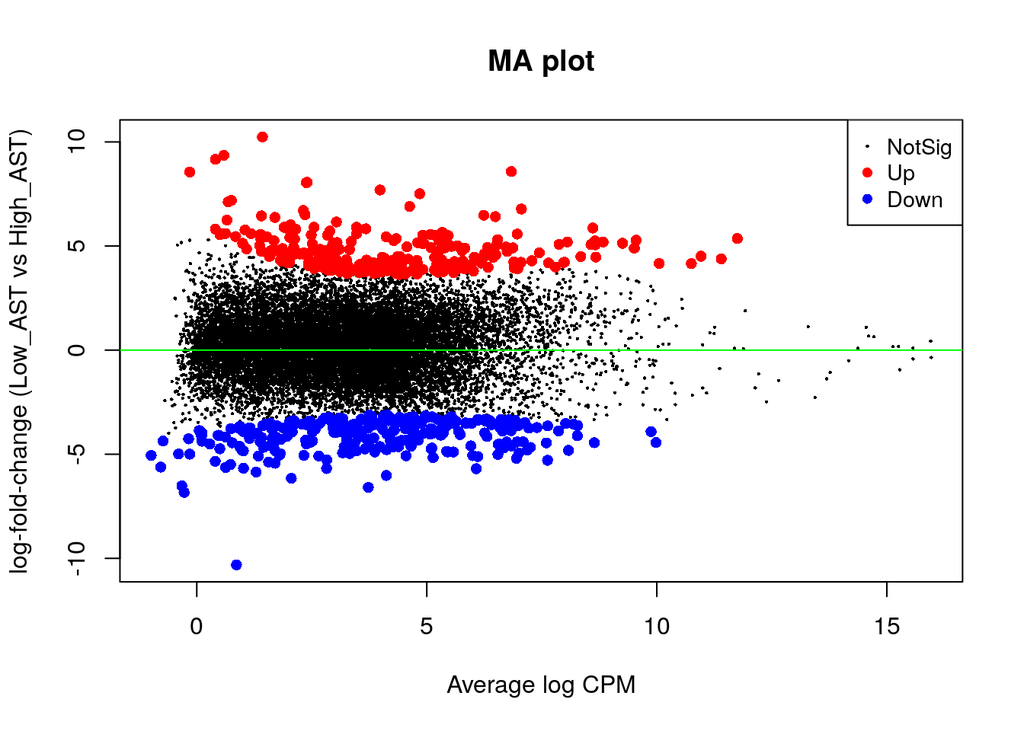

```r
edgeR::plotMD.DGELRT(qlf.low_vs_high, xlab="Average log CPM", ylab="log-fold-change (Low_AST vs High_AST)",
       main="MA plot", status=NULL,
       p.value=0.000001)
abline(h = 0, col="green")
```

**Figure 4:** MA plot of the Differential gene expression analysis between the Low AST<40 condition and the High AST>40 condition. Upregulated significant genes are red and down regulated significant genes are blue.

## Heat Map

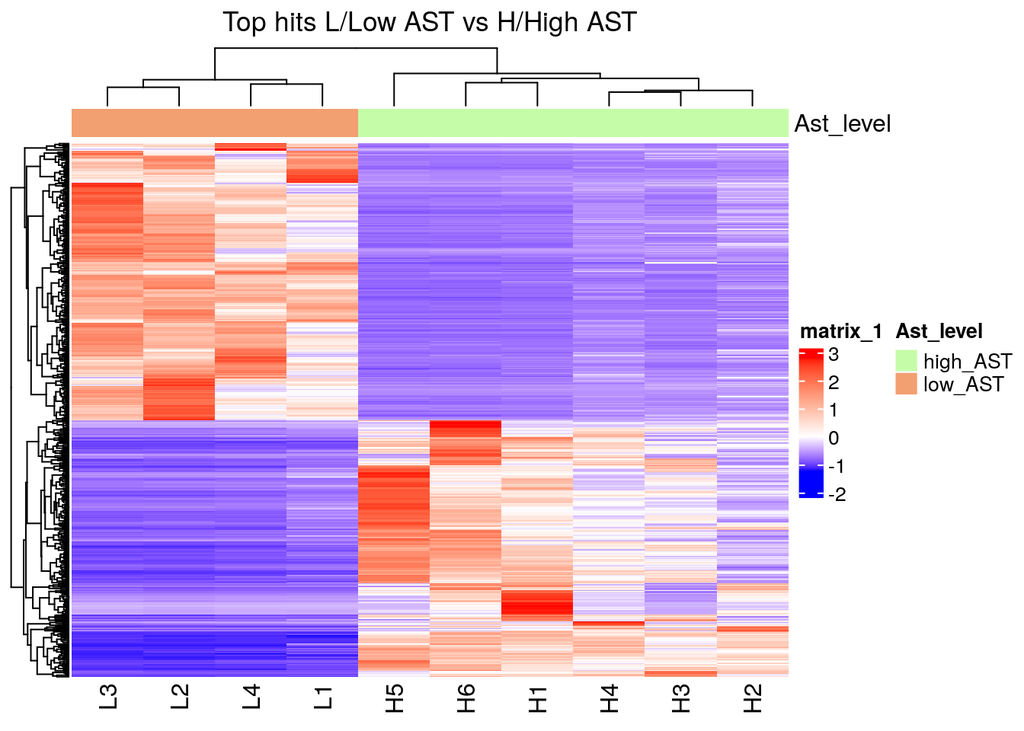

```r
# Get the dataframe with the expression results for the signnificant genes
significant_genes_df <- qlf_output_hits$table[qlf_output_hits$table$FDR < 0.000001, ]

# extract the significant gene names
significant_genes <- row.names(significant_genes_df)

# keep the normalized counts for the significant genes only
significant_counts <- normalized_counts[unlist(significant_genes), ]

# install packages if not installed
if (!requireNamespace('ComplexHeatmap', quietly = TRUE)) {
    install.packages('ComplexHeatmap')
}
if (!requireNamespace('circlize', quietly = TRUE)) {
    install.packages('circlize')
}

# Scale the counts data so that down regulated genes are blue and upregulated genes are red providing greater contrast for comparison of expression
heatmap_matrix <- t(scale(t(significant_counts)))

# Set colours for expression difference
if(min(heatmap_matrix) == 0){
  heatmap_col = circlize::colorRamp2(c( 0, max(heatmap_matrix)),
                           c( "white", "red"))
  } else {
    heatmap_col = circlize::colorRamp2(c(min(heatmap_matrix), 0,
                               max(heatmap_matrix)), c("blue", "white", "red"))
  }

# set colours to represent samples from each condition
unique_ast_level_colors = rainbow(n=2)
names(unique_ast_level_colors) <- c("low_AST", "high_AST")

# create annotations with the chosen colours
ha_pat <- ComplexHeatmap::HeatmapAnnotation(df = data.frame(
  Ast_level = c('low_AST', 'low_AST', 'low_AST', 'low_AST', 'high_AST', 'high_AST', 'high_AST', 'high_AST', 'high_AST', 'high_AST')))

# Plot heatmap
current_heatmap <- ComplexHeatmap::Heatmap(as.matrix(heatmap_matrix),
                           top_annotation = ha_pat,
                           show_row_dend = TRUE,show_column_dend = TRUE,
                           col=heatmap_col,show_column_names = TRUE,
                           show_row_names = FALSE,show_heatmap_legend = TRUE,
                           column_title =("Top hits L/Low AST vs H/High AST"))
current_heatmap
```

**Figure 5:** The heatmap showcasing the difference in expression between the two conditions (Low AST<40 and High AST>40), and the samples L1-L4 and H1-H6.

# Thresholded Over-Representation Analysis

Next we carried out Thresholded over-representation analysis or Gene Set Enrichment Analysis (GSEA). This analysis is conducted to help us identify biological processes, molecular functions, and cellular components that are significantly enriched in our gene list. This means it reveals what processes or functions are overrepresented in our dataset, suggesting the biological themes that our genes are involved in.

## Upregulated and Down Regulated Genes

By looking at the genes that pass our previously set threshold for correction and looking at whether their logFC or Log Fold Count values above or below 0, we can know which genes of interest are upregulated or down regulated respectively.

```r
# Number of upregulated Genes
sprintf("There are %d upregulated genes",
        length(which(significant_genes_df$logFC > 0)))
```

```
## [1] "There are 257 upregulated genes"
```

```r
# Number of down-regulated Genes
sprintf("There are %d down-regulated genes",
        length(which(significant_genes_df$logFC < 0)))
```

```
## [1] "There are 277 down-regulated genes"
```

## Selecting GSEA tool

To carry out the Gene Set Enrichment, I chose the G:Profiler tool. G:Profiler was the recommended and ideal choice for this project as it has a wide range of gene sets. It also has an accessible easy to use r package that is updated regularly with the last update being last month.

## Extracting differently regulated genes

The first thing to do is to create sets of for the significant genes, upregulated significant genes and down regulated significant genes. This will allow us to then run the enrichment analysis on the whole set of genes and then on the differently regulated genes seperately.

```r
significant_genes <- row.names(significant_genes_df)

upregulated_significant_genes <- row.names(subset(significant_genes_df, logFC > 0))

down_regulated_significant_genes <- row.names(subset(significant_genes_df, logFC < 0))
```

## Carrying Out The Enrichment Analysis

### Annotation Sources

For the annotation sources I used GO biological process (GO:BP), WikiPathways (WP) and Reactome (Reac). I used them as they are excellent choices for gene enrichment analysis due to their comprehensive coverage, detailed annotation, and widespread recognition within the scientific community. They are all frequently updated making them reliable sources. The integration of results across these three databases enhances the reliability of the findings and provides a robust framework for interpreting the biological implications of genomic data. By not specifying the versions of the annotation sources, the g:profiler function automatically uses the lastest versions of the annotations sources.

### Non-size Restricted All Significant Genes GSEA

Below is the code for the gene enrichment analysis for the whole gene list. The results of the gene enrichment can be seen in the Table below. This Table shows us the term name of the top hits from gene sets by P-value. This shows the most relevant gene sets and the pathways or biological mechanisms they are involved in. The table is accompanied by a plot of the gene enrichment results showing the number of gene sets in the results for each data source. The number of genes in each gene set is represented by the size of the dot representing that gene set so a bigger dot is a larger sized gene set.

Tables are produced using the kable package (Zhu (2021)) and plot of enrichment analysis created using gprofiler2 package (Kolberg et al. (2020))

```r
# Ensure the gprofiler2 package is installed
if (!requireNamespace("gprofiler2", quietly = TRUE)) {
  install.packages("gprofiler2")
}

# Conduct gene enrichment analysis
whole_gene_results <- gprofiler2::gost(query = significant_genes,
                     organism = "hsapiens",
                     significant= TRUE,
                     ordered_query = FALSE,
                     exclude_iea=TRUE,
                     sources = c("GO:BP", "WP", "REAC"),  # GO BP, WikiPathways, Reactome
                     correction_method = "fdr",
                     user_threshold = 0.000001)

sprintf("There are %s gene sets in the Non-size restricted All genes GSEA results", length(row.names(whole_gene_results$result)))
```

```
## [1] "There are 7 gene sets in the Non-size restricted All genes GSEA results"
```

```r
# Show table of results
kableExtra::kable(whole_gene_results$result[, c("term_name", "p_value", "term_size", "source")], type="html", row.names =FALSE, digits = 12, padding="300", align="c")
```

| term_name | p_value | term_size | source |
| --- | --- | --- | --- |
| Regulation of Complement cascade | 3.36080e-08 | 101 | REAC |
| Complement cascade | 7.90980e-08 | 111 | REAC |
| Classical antibody-mediated complement activation | 1.08514e-07 | 61 | REAC |
| Metabolism | 1.69545e-07 | 2074 | REAC |
| FCGR activation | 2.24320e-07 | 67 | REAC |
| Creation of C4 and C2 activators | 2.26743e-07 | 68 | REAC |
| Initial triggering of complement | 8.12096e-07 | 76 | REAC |

**Table 3:** The above table showcases the Term names, term_sizes or gene set sizes, P-value associated with the gene set and source of the gene set for the All significant genes GSEA results before size restriction.

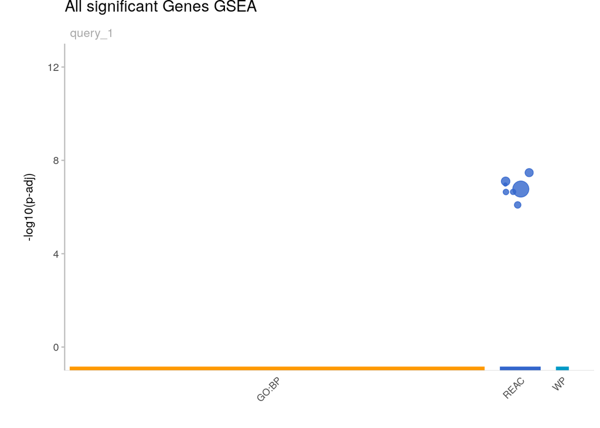

```r
# plot enrichment whole gene list enrichment analysis
enrich_plot <- gprofiler2::gostplot(whole_gene_results, capped = FALSE, interactive = FALSE)

# add a title
enrich_plot_with_title <- enrich_plot + ggplot2::ggtitle("All significant Genes GSEA")
enrich_plot_with_title
```

**Figure 6:** The above figure show the plot of the Gene Set Enrichment Analysis results. The dot colours signify which source the gene sets are coming from. The size of the dots represent the size of the gene sets.

### Size Restricted All Significant Genes GSEA

Despite the initial number of gene set results not being particularly high, I decided to apply restrictions on the size of these gene sets for several reasons. Firstly, focusing on gene sets of moderate size enhances the statistical robustness and biological relevance of our findings. This approach aids in avoiding potential overinterpretation of results driven by very small gene sets, which may lack statistical confidence, and overly broad interpretations from excessively large gene sets, which can dilute specific biological insights. Still I set the Max size restriction to be 800 as the significance threshold was really stringent and so we actually have some gene sets in the results. The Min size restriction was set to 5.

```r
# restrict the size of the results
size_restricted_results <- whole_gene_results$result[which(whole_gene_results$result$term_size >=5 & whole_gene_results$result$term_size <=800),]

whole_gene_results$result <- size_restricted_results

sprintf("There are %s gene sets in the size restricted All genes GSEA results", length(row.names(whole_gene_results$result)))
```

```
## [1] "There are 6 gene sets in the size restricted All genes GSEA results"
```

```r
# Show table of results
kableExtra::kable(whole_gene_results$result[, c("term_name", "p_value", "term_size", "source")], type="html",row.names =FALSE, digits = 12, padding="300", align="c")
```

| term_name | p_value | term_size | source |
| --- | --- | --- | --- |
| Regulation of Complement cascade | 3.36080e-08 | 101 | REAC |
| Complement cascade | 7.90980e-08 | 111 | REAC |
| Classical antibody-mediated complement activation | 1.08514e-07 | 61 | REAC |
| FCGR activation | 2.24320e-07 | 67 | REAC |
| Creation of C4 and C2 activators | 2.26743e-07 | 68 | REAC |
| Initial triggering of complement | 8.12096e-07 | 76 | REAC |

**Table 4:** The above table showcases the Term names, term_sizes or gene set sizes, P-value associated with the gene set and source of the gene set for the size restricted All genes GSEA results.

## Up and Down Regulated Genes GSEA

Next we ran the Gene set enrichment analysis on the upregulated and the down regulated list of significant genes separately. This allowed to see which biological pathways and mechanisms specifically were most relevant to the High AST>40 condition and which were most relevant to the Low AST<40 condition. We went with the restricted gene set size results as the default here.

### Upregulated GSEA

```r
# Conduct gene enrichment analysis
upregulated_genes_results <- gprofiler2::gost(query = upregulated_significant_genes,
                     organism = "hsapiens",
                     significant=TRUE,
                     ordered_query = FALSE,
                     exclude_iea=TRUE,
                     sources = c("GO:BP", "WP", "REAC"),  # GO BP, WikiPathways, Reactome
                     correction_method = "fdr",
                     user_threshold = 0.000001)


size_restricted_results <- upregulated_genes_results$result[which(upregulated_genes_results$result$term_size >=5 & upregulated_genes_results$result$term_size <=800),]

upregulated_genes_results$result <- size_restricted_results

sprintf("There are %s gene sets in the upregulated genes GSEA results", length(row.names(upregulated_genes_results$result)))
```

```
## [1] "There are 37 gene sets in the upregulated genes GSEA results"
```

```r
# Show table of results
kableExtra::kable(upregulated_genes_results$result[1:10, c("term_name", "p_value", "term_size", "source")], type="html",row.names =FALSE, digits = 12, padding="300", align="c")
```

| term_name | p_value | term_size | source |
| --- | --- | --- | --- |
| B cell mediated immunity | 2.11800e-09 | 147 | GO:BP |
| immunoglobulin mediated immune response | 2.11800e-09 | 142 | GO:BP |
| external encapsulating structure organization | 1.51560e-08 | 237 | GO:BP |
| extracellular structure organization | 1.51560e-08 | 236 | GO:BP |
| extracellular matrix organization | 1.51560e-08 | 235 | GO:BP |
| lymphocyte mediated immunity | 5.41829e-07 | 269 | GO:BP |
| collagen metabolic process | 5.41829e-07 | 70 | GO:BP |
| adaptive immune response based on somatic recombination of immune receptors built from immunoglobulin superfamily domains | 5.85220e-07 | 274 | GO:BP |
| Classical antibody-mediated complement activation | 1.00000e-11 | 61 | REAC |
| FCGR activation | 1.50000e-11 | 67 | REAC |

**Table 5:** The above table showcases the Term names, term_sizes or gene set sizes, P-value associated with the gene set and source of the gene set for the size upregulated genes GSEA results

### Down Regulated GSEA

Below is the code for the down regulated genes GSEA. After it we display a table to showcase the top 10 gene sets by significance in P-value. The term_name lets us know the most significant and relevant biological pathways in the down regulated GSEA results.

```r
# Conduct gene enrichment analysis
down_regulated_genes_results <- gprofiler2::gost(query = down_regulated_significant_genes,
                     organism = "hsapiens",
                     significant= TRUE,
                     ordered_query = FALSE,
                     exclude_iea=TRUE,
                     sources = c("GO:BP", "WP", "REAC"),  # GO BP, WikiPathways, Reactome
                     correction_method = "fdr",
                     user_threshold = 0.000001)

size_restricted_results <- down_regulated_genes_results$result[which(down_regulated_genes_results$result$term_size >=5 & down_regulated_genes_results$result$term_size <=800),]

down_regulated_genes_results$result <- size_restricted_results

sprintf("There are %s gene sets in the down regulated genes GSEA results", length(row.names(down_regulated_genes_results$result)))
```

```
## [1] "There are 22 gene sets in the down regulated genes GSEA results"
```

```r
# Show table of results
kableExtra::kable(down_regulated_genes_results$result[1:10, c("term_name", "p_value", "term_size", "source")], type="html",row.names =FALSE, digits = 21, padding="300", align="c")
```

| term_name | p_value | term_size | source |
| --- | --- | --- | --- |
| organic acid metabolic process | 4.630620e-16 | 764 | GO:BP |
| oxoacid metabolic process | 4.630620e-16 | 758 | GO:BP |
| carboxylic acid metabolic process | 3.540655e-14 | 739 | GO:BP |
| small molecule catabolic process | 1.722740e-10 | 299 | GO:BP |
| steroid metabolic process | 2.095737e-10 | 242 | GO:BP |
| organic hydroxy compound metabolic process | 1.030415e-08 | 412 | GO:BP |
| small molecule biosynthetic process | 2.943079e-08 | 481 | GO:BP |
| response to toxic substance | 4.825718e-08 | 95 | GO:BP |
| organic acid catabolic process | 8.135512e-08 | 211 | GO:BP |
| carboxylic acid catabolic process | 8.135512e-08 | 211 | GO:BP |

**Table 6:** The above table showcases the Term names, term_sizes or gene set sizes, P-value associated with the gene set and source of the gene set for the size down regulated genes GSEA results

## Analysis Comparison (Whole Gene List vs Upregulated vs Downregulated)

The Gene Set Enrichment Analysis (GSEA) provides a distinct overview of the biological processes implicated in High AST>40 versus Low AST<40 conditions through the evaluation of all significant genes and the subsets of upregulated and downregulated genes.

When looking at the overall significant genes the GSEA identifies 6 gene sets. However, it identifies 20+ gene sets for both the up and down regulated genes GSEA results. So quite a smaller number of gene sets in the results of the overall significant genes GSEA

For the upregulated genes in the High AST>40 samples, the GSEA reveals enrichment in immune system-related processes, including B cell mediated immunity and complement system activation. This suggests a heightened immune response or activation of immune pathways in the context of higher AST levels.

In contrast, the downregulated genes in the High AST>40 samples exhibit enrichment in a variety of metabolic processes, including organic acid, carboxylic acid, and amino acid metabolic processes. The downregulation of these genes points to a potential suppression or disruption of metabolic pathways in patients with higher AST levels.

# Interpretation

## Do the over-representation results support conclusions or mechanism discussed in the original paper?

Yes, the over-representation results do support the conslusions that the authors of the original paper reached. They mainly focused on the upregulation of immune response related genes such as IL1β and IL8 which play roles in chemotaxis and activation of neutrophils Liu et al. (2023). Although these genes were removed when we made our threshold more stringent to get a lower number of genes that pass correction, the over-representation results for the upregulated genes show that most of the top hits have do with the immune system and immune responses as a whole.

## Supporting Evidence

This is supported by papers such as that by Polyak et al. (2001) that show that il8 gene plays a role in the recruiting of neutrophils (an immune pathways related response) to exacerbate inflammation-mediated liver injury. Thus, are results are correct in suggesting that the upregulated genes in the High AST>40 group of samples would have the most relevant biological pathways or gene sets be.

# Assignment Handout Question Links

I will provide the questions in the rubric and the link to the section/subsection where the question is addressed.

**Differential Gene Expression Questions:**

1. Calculate p-values for each of the genes in your expression set. How many genes were significantly differentially expressed? What thresholds did you use and why?

   Threshold Selection
2. Multiple hypothesis testing - correct your p-values using a multiple hypothesis correction method. Which method did you use? And Why? How many genes passed correction?  
   Multiple Hypothesis Testing & Threshold Selection
3. Show the amount of deferentially expressed genes using an MA Plot or a Volcano plot. Highlight genes of interest.  
   MA plot
4. Visualize your top hits using a heatmap. Do you conditions cluster together? Explain why or why not.

   Heat Map

**Thresholded over-representation analysis:**

1. Which method did you choose and why?

   Selecting GSEA tool
2. What annotation data did you use and why? What version of the annotation are you using?

   Annotation Sources
3. How many genesets were returned with what thresholds?

   Non-size Restricted All Significant Genes GSEA & Size Restricted All Significant Genes GSEA
4. Run the analysis using the up-regulated set of genes, and the down-regulated set of genes separately. How do these results compare to using the whole list (i.e all differentially expressed genes together vs. the up-regulated and down regulated differentially expressed genes separately)

   Up and Down Regulated Genes GSEA & Analysis Comparison (Whole Gene List vs Upregulated vs Downregulated)

**Interpretation:**

1. Do the over-representation results support conclusions or mechanism discussed in the original paper?  
   Do the over-representation results support conclusions or mechanism discussed in the original paper?
2. Can you find evidence, i.e. publications, to support some of the results that you see. How does this evidence support your results.

   Supporting Evidence

# References

Chen, Yunshun, Aaron TL Lun, Davis J McCarthy, Lizhong Chen, Matthew E Ritchie, Belinda Phipson, Yifang Hu, Xiaobei Zhou, Mark D Robinson, and Gordon K Smyth. 2023. *edgeR: Empirical Analysis of Digital Gene Expression Data in r*. https://doi.org/10.18129/B9.bioc.edgeR.

Gu, Zuguang. 2022. “Complex Heatmap Visualization.” *iMeta*. https://doi.org/10.1002/imt2.43.

Kolberg, Liis, Uku Raudvere, Ivan Kuzmin, Jaak Vilo, and Hedi Peterson. 2020. “Gprofiler2– an r Package for Gene List Functional Enrichment Analysis and Namespace Conversion Toolset g:profiler.” *F1000Research* 9 (ELIXIR) (709).

Liu, Yu, Wei Wang, Peng Zhu, Xue Cheng, Mi Wu, Haoquan Zhang, Yiqing Chen, et al. 2023. “Increased Non-MAIT CD161+ CD8+ t Cells Display Pathogenic Potential in Chronic HBV Infection.” *Cellular and Molecular Gastroenterology and Hepatology* 15 (5): 1181–98.

Polyak, Stephen J, Khalid SA Khabar, Mohammed Rezeiq, and David R Gretch. 2001. “Elevated Levels of Interleukin-8 in Serum Are Associated with Hepatitis c Virus Infection and Resistance to Interferon Therapy.” *Journal of Virology* 75 (13): 6209–11.

Xie, Yihui. 2023. *Knitr: A General-Purpose Package for Dynamic Report Generation in r*. https://yihui.org/knitr/.

Zhu, Hao. 2021. *kableExtra: Construct Complex Table with Kable and Pipe Syntax*. http://haozhu233.github.io/kableExtra/.